# Data leakage due to feature selection using the information of the classes.

## Create simulated data

I create a dataset with 2000 rows - samples and 20.000 features. All data are drown from the normal distribution with `mean = 0` and `standard deviation = 1` using `rnorm()` function. Then, I assigned half of the samples to class 0 and the other half to class 1.

```r
set.seed(42)
library(glmnet)
mydata_all <- matrix(
    data = rnorm(n = 2000 * 20000),
    nrow = 2000, ncol = 20000
)
rownames(mydata_all) <- paste0("s", 1:nrow(mydata_all))
colnames(mydata_all) <- paste0("g", 1:ncol(mydata_all))
classes <- rep(c(0, 1), times = nrow(mydata_all) / 2)
mydata_all[1:5, 1:5]
```

```
##            g1         g2         g3         g4          g5
## s1  1.3709584  0.2505781 -0.1418087  0.1728323 -0.05745257
## s2 -0.5646982 -0.2779240 -0.8138981 -1.2729637 -0.24903540
## s3  0.3631284 -1.7247357 -0.3255406 -0.8678954 -1.52416211
## s4  0.6328626 -2.0067049  0.3781574  0.6263211  0.46359103
## s5  0.4042683 -1.2918083 -1.9944854 -0.1056306 -1.18762073
```

## Spit the data

I split the data to `test_data_external`, `test_y_external` and `mydata_x`, `mydata_y`. The first two correspond to an external dataset that will never been used in the model building. Thus we will be able to evaluate the **true** performance of our model. The latter will be used in model building.

```r
test_data_external <- mydata_all[1501:2000, ]
test_y_external <- classes[1501:2000]
mydata_x <- mydata_all[1:1500, ]
mydata_y <- classes[1:1500]
```

## Perform feature selection using the class information

I perform a `t.test()` to identify statistical significant features using the `mydata_x` data and keep the features that have a `p.value < 0.05`.

```r
pvalues <- sapply(
    X = 1:ncol(mydata_x), function(i) {
        t.test(
            x = mydata_x[mydata_y == 0, i],
            y = mydata_x[mydata_y == 1, i]
        )$p.value
    }
)
mydata_x <- mydata_x[, pvalues < 0.05]
cat("Number of genes kept:", ncol(mydata_x), "\n")
```

```
## Number of genes kept: 1019
```

## Split train - test

I split the data `mydata_x` in train `train_data` and test `test_data` sets to build a model and evaluate its performance.

```r
train_data <- mydata_x[1:1000, ]
train_y <- mydata_y[1:1000]
test_data <- mydata_x[1001:1500, ]
test_y <- mydata_y[1001:1500]
```

## Build ElasticNet model

I build the ElasticNet model and plot its cross validation error

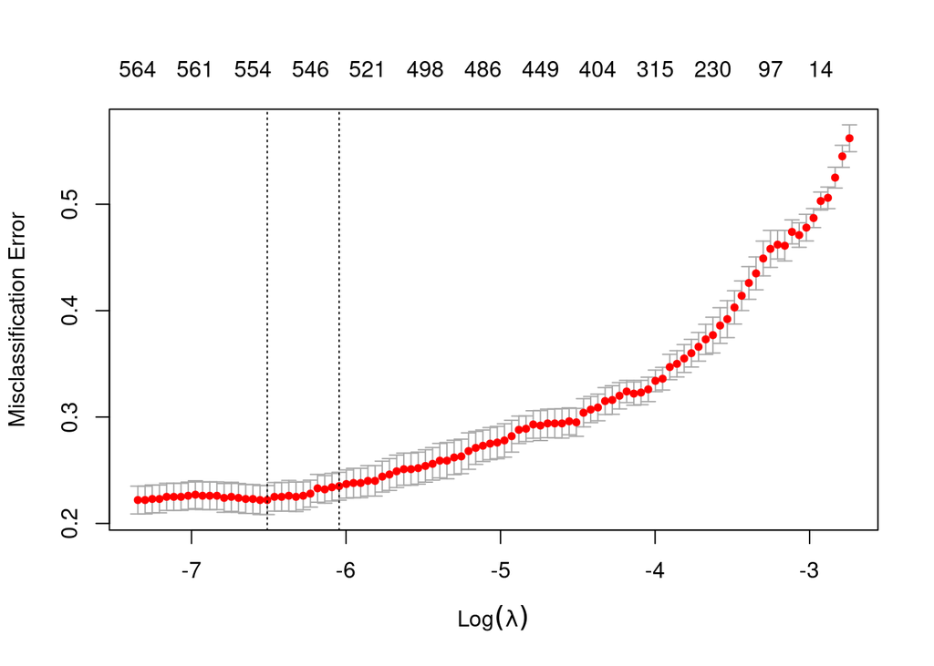

```r
fit_glmnet <- cv.glmnet(
    x = train_data, y = train_y, family = "binomial",
    type.measure = "class"
)
plot(fit_glmnet)
```

Note that the model has a misclassification accuracy of ~0.2 while we know that all the data were drown from the normal distribution with the same mean and standard deviation and thus they contain no signal!!

## Test after feature selection

I test the model on the `test_data`. The set that I kept out after the feature selection.

```r
preds <- predict(
    object = fit_glmnet,
    newx = test_data, s = "lambda.min",
    type = "class"
)
cat("Misclassification Error of test_data:", 1 - mean(preds == test_y), "\n")
```

```
## Misclassification Error of test_data: 0.238
```

The Misclassification Error in the this set that I selected is similar to the cross validation Misclassification Error, as expected.

## Test in the TRUE external set

Finally we test the model on the external set that did not went through feature selection.

```r
preds_external <- predict(
    object = fit_glmnet,
    newx = test_data_external[, pvalues < 0.05],
    s = "lambda.min",
    type = "class"
)
cat(
    "Misclassification Error of test_data_external:",
    1 - mean(preds_external == test_y_external), "\n"
)
```

```
## Misclassification Error of test_data_external: 0.508
```

We observe that the **true** Misclassification Error is ~0.5 that is expected because the similated dataset has equal number of samples belonging to class 0 and class 1.

# Rerun without feature selection

Rerunning without feature selection we observe that the three misclassification errors agree, the `cv error`, the error on the `test_data` and the error on the `external_data`.

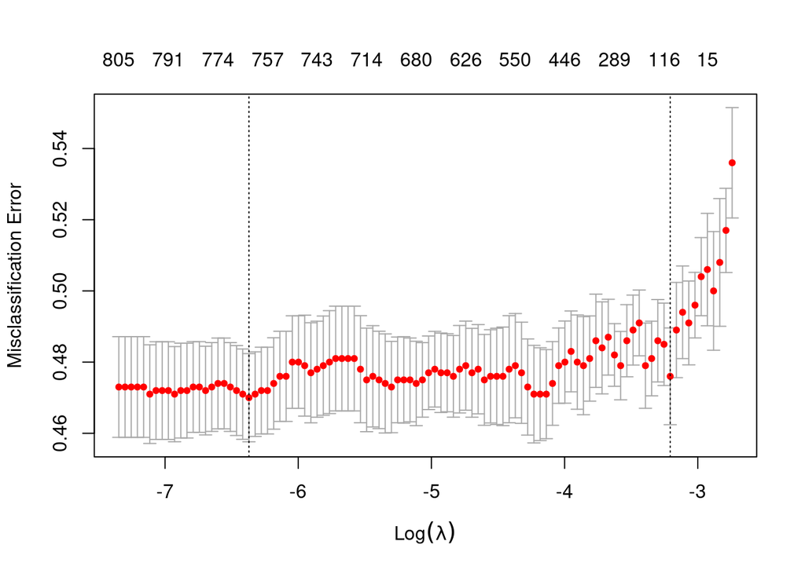

```r
# Split the data again
rm(train_data, test_data)
test_data_external <- mydata_all[1501:2000, ]
test_y_external <- classes[1501:2000]
mydata_x <- mydata_all[1:1500, ]
mydata_y <- classes[1:1500]
train_data <- mydata_x[1:1000, ]
train_y <- mydata_y[1:1000]
test_data <- mydata_x[1001:1500, ]
test_y <- mydata_y[1001:1500]
# Model fitting
fit_glmnet <- cv.glmnet(
    x = train_data, y = train_y, family = "binomial",
    type.measure = "class"
)
plot(fit_glmnet)
```

```r
# Prediction on test data
preds <- predict(
    object = fit_glmnet,
    newx = test_data, s = "lambda.min",
    type = "class"
)
cat("Misclassification Error of test_data:", 1 - mean(preds == test_y))
```

```
## Misclassification Error of test_data: 0.506
```

```r
# Prediction on external data
preds_external <- predict(
    object = fit_glmnet,
    newx = test_data_external,
    s = "lambda.min",
    type = "class"
)
cat(
    "Misclassification Error of test_data_external:",
    1 - mean(preds_external == test_y_external),
    "\n"
)
```

```
## Misclassification Error of test_data_external: 0.49
```